# Random Forest로 하는 은행 텔레마케팅 결과 예측

# 재무금융전공 석사2기

# 2021194458 왕몽요

## 1. 연구 배경

- 요즘 들어 IT와 금융계의 관계가 점점 긴밀해지고 있다. 금융 종업자에게 데이터로부터 필요한 정보를 찾아내는 것은 중요하지만 고객의 기왕 자료에 대해 깊이 발굴하지 않은 경우가 있다. 예를 들면, 금융 상품의 보급도를 분석했을 때, 시장 점유율만 고려해 고객의 나이, 직업, 수입 등 요소를 잘 이용하지 않은 점은 아쉽다.

## 2. 데이터 준비

- UCI Machine Learning Repository 데이터베이스에서 제공한 프로투갈 한 은행 2008년 5월- 2010년 11월 총 4521의 텔레마케팅 데이터 사용
- [링크](http://archive.ics.uci.edu/ml/datasets/Bank+Marketing)

## 3. 데이터 소개 및 분석

| 변수 이름 | 설명 |
| --- | --- |
| age | 나이 |
| job | 직업 |
| marital | 결혼 여부 |
| education | 학력 |
| default | 신용 부도 여부 |
| balance | 연평균 계정잔고 |
| housing | 주택자금 대출 여부 |
| loan | 개인융자 여부 |
| contact | 연락처 종류 |
| duration | 통화 지속시간 |
| campaign | 이 저금 프로젝트를 위한 통화 횟수 |
| pdays | 최근 통화가 며칠 지났는지 |
| previous | 이 프로젝트 시작하기 전의 통화 횟수 |
| poutcome | 이전 프로젝트 결과 |
| y | 이 저금 프로젝트에 참여 여부 |

### 3.1 변수간 상관관계 및 다중공선성 분석

```python
import pandas as pd
import numpy as np
import matplotlib.pyplot as plt
import seaborn as sns

sns.set()
sns.set_style('whitegrid')

df = pd.read_excel("/Users/wangmengyao/Desktop/jieguo.xlsx")
df.corr()
```

|  | age | job | marital | education | default | balance | housing | loan | contact | duration | campaign | pdays | previous | poutcome | y |
| --- | --- | --- | --- | --- | --- | --- | --- | --- | --- | --- | --- | --- | --- | --- | --- |
| age | 1.000000 | 0.252828 | -0.123804 | -0.121613 | -0.017885 | 0.083820 | -0.193888 | -0.011250 | 0.015161 | -0.002367 | -0.005148 | -0.008894 | -0.003511 | -0.034240 | 0.045092 |
| job | 0.252828 | 1.000000 | -0.012186 | -0.088132 | -0.002168 | 0.045592 | -0.160040 | 0.001375 | -0.037670 | -0.012931 | -0.042118 | 0.000564 | 0.020836 | -0.047205 | 0.068978 |
| marital | -0.123804 | -0.012186 | 1.000000 | 0.090907 | 0.049837 | -0.028742 | -0.027397 | -0.014321 | -0.021157 | 0.035321 | -0.025599 | 0.009975 | 0.002087 | 0.004894 | 0.061242 |
| education | -0.121613 | -0.088132 | 0.090907 | 1.000000 | -0.010534 | 0.057725 | -0.087070 | -0.054086 | -0.110554 | -0.014878 | -0.001723 | 0.012077 | 0.023983 | -0.042276 | 0.042987 |
| default | -0.017885 | -0.002168 | 0.049837 | -0.010534 | 1.000000 | -0.070886 | 0.006881 | 0.063994 | 0.008448 | -0.011615 | -0.012348 | -0.026317 | -0.026656 | 0.044546 | 0.001303 |
| balance | 0.083820 | 0.045592 | -0.028742 | 0.057725 | -0.070886 | 1.000000 | -0.050227 | -0.071349 | -0.009665 | -0.015950 | -0.009976 | 0.009437 | 0.026196 | -0.039555 | 0.017905 |
| housing | -0.193888 | -0.160040 | -0.027397 | -0.087070 | 0.006881 | -0.050227 | 1.000000 | 0.018451 | 0.196454 | 0.015740 | -0.003574 | 0.116893 | 0.038621 | -0.030600 | -0.104683 |
| loan | -0.011250 | 0.001375 | -0.014321 | -0.054086 | 0.063994 | -0.071349 | 0.018451 | 1.000000 | -0.007319 | -0.004997 | 0.017120 | -0.031086 | -0.022115 | 0.046311 | -0.070517 |
| contact | 0.015161 | -0.037670 | -0.021157 | -0.110554 | 0.008448 | -0.009665 | 0.196454 | -0.007319 | 1.000000 | -0.011380 | 0.012278 | -0.243223 | -0.187232 | 0.264312 | -0.133595 |
| duration | -0.002367 | -0.012931 | 0.035321 | -0.014878 | -0.011615 | -0.015950 | 0.015740 | -0.004997 | -0.011380 | 1.000000 | -0.068382 | 0.010380 | 0.018080 | -0.023307 | 0.401118 |
| campaign | -0.005148 | -0.042118 | -0.025599 | -0.001723 | -0.012348 | -0.009976 | -0.003574 | 0.017120 | 0.012278 | -0.068382 | 1.000000 | -0.093137 | -0.067833 | 0.119648 | -0.061147 |
| pdays | -0.008894 | 0.000564 | 0.009975 | 0.012077 | -0.026317 | 0.009437 | 0.116893 | -0.031086 | -0.243223 | 0.010380 | -0.093137 | 1.000000 | 0.577562 | -0.796937 | 0.104087 |
| previous | -0.003511 | 0.020836 | 0.002087 | 0.023983 | -0.026656 | 0.026196 | 0.038621 | -0.022115 | -0.187232 | 0.018080 | -0.067833 | 0.577562 | 1.000000 | -0.629897 | 0.116714 |
| poutcome | -0.034240 | -0.047205 | 0.004894 | -0.042276 | 0.044546 | -0.039555 | -0.030600 | 0.046311 | 0.264312 | -0.023307 | 0.119648 | -0.796937 | -0.629897 | 1.000000 | -0.205732 |
| y | 0.045092 | 0.068978 | 0.061242 | 0.042987 | 0.001303 | 0.017905 | -0.104683 | -0.070517 | -0.133595 | 0.401118 | -0.061147 | 0.104087 | 0.116714 | -0.205732 | 1.000000 |

- 더 선명하게 보이기 위해 heatmap 사용

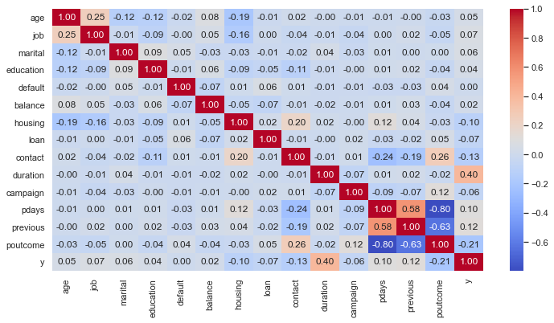

```python
plt.figure(figsize=(12,6))
sns.heatmap(df.corr(),annot=True, fmt=".2f", cmap = "coolwarm")
```

- 상관관계 수치를 통해 변수 pdays, previous와 poutcome간의 상관관계가 높은 걸을 알 수 있다

### 3.2 Box Plot로 변수 식별력 검증

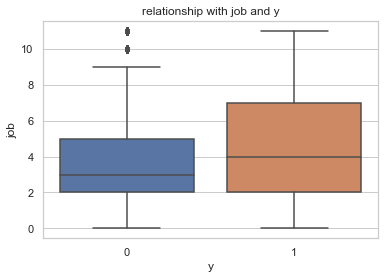

```python
import matplotlib as plt
from matplotlib import pyplot
import seaborn as sns

sns.boxplot(x= "y" , y= "job",data=df)
plt.pyplot.title("relationship with job and y")
plt.pyplot.show()
```

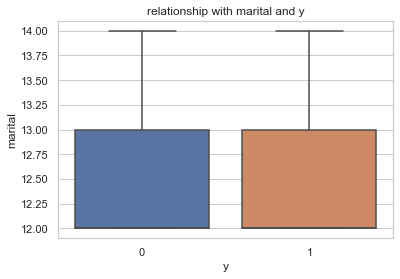

```python
import matplotlib as plt
from matplotlib import pyplot
import seaborn as sns
df = pd.read_excel("/Users/wangmengyao/Desktop/jieguo.xlsx")
sns.boxplot(x= "y" , y= "marital",data=df)
plt.pyplot.title("relationship with marital and y")
plt.pyplot.show()
```

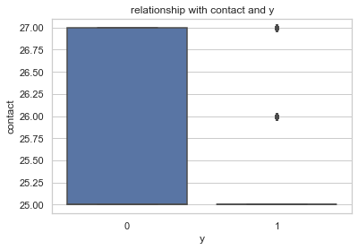

```python
sns.boxplot(x= "y" , y= "contact",data=df)
plt.pyplot.title("relationship with contact and y")
plt.pyplot.show()
```

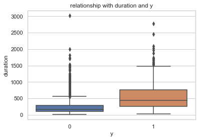

```python
sns.boxplot(x= "y" , y= "duration",data=df)
plt.pyplot.title("relationship with duration and y")
plt.pyplot.show()
```

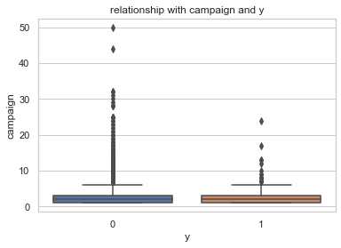

```python
sns.boxplot(x= "y" , y= "campaign",data=df)
plt.pyplot.title("relationship with campaign and y")
plt.pyplot.show()
```

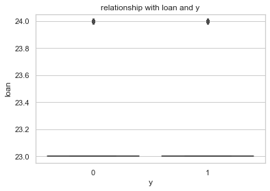

```python
sns.boxplot(x= "y" , y= "loan",data=df)
plt.pyplot.title("relationship with loan and y")
plt.pyplot.show()
```

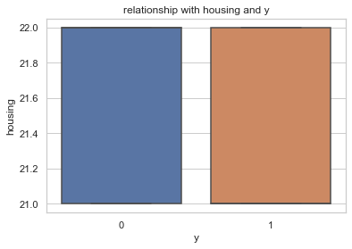

```python
sns.boxplot(x= "y" , y= "housing",data=df)
plt.pyplot.title("relationship with housing and y")
plt.pyplot.show()
```

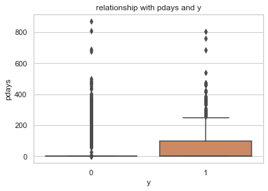

```python
sns.boxplot(x= "y" , y= "pdays",data=df)
plt.pyplot.title("relationship with pdays and y")
plt.pyplot.show()
```

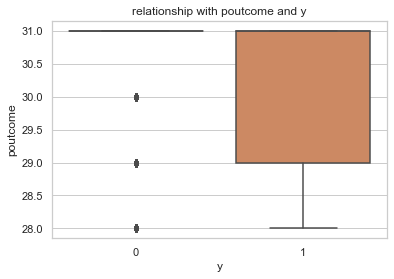

```python
sns.boxplot(x= "y" , y= "poutcome",data=df)
plt.pyplot.title("relationship with poutcome and y")
plt.pyplot.show()
```

## 3.3 decision tree 만들기

```python
from sklearn.metrics import classification_report, confusion_matrix
from sklearn.model_selection import train_test_split
from sklearn.tree import DecisionTreeClassifier
from sklearn import tree

from IPython.display import Image

import pandas as pd
import numpy as np
import pydotplus
import os
os.environ["PATH"] += os.pathsep

data = pd.read_excel("/Users/wangmengyao/Desktop/jieguo.xlsx")
data

X = np.array(pd.DataFrame(data, columns = ['job','contact','duration','poutcome']))
y = np.array(pd.DataFrame(data, columns = ['y']))
```

- 4521개 데이터를 7:3으로 나뉘어 (7: 훈련 데이터, 3: 테스트 데이터) 트리를 훈련한다.

```python
from sklearn.model_selection import train_test_split
X_train, X_test, y_train, y_test = train_test_split(X, y, test_size=0.3, random_state=101)

from sklearn.ensemble import RandomForestClassifier
```

```
<sklearn.metrics._plot.confusion_matrix.ConfusionMatrixDisplay at 0x7fa6ca2d0040>
```

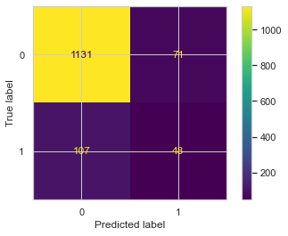

```python
import pandas as pd
import numpy as np
model = RandomForestClassifier(n_estimators=10,max_features='auto',random_state=101)
model.fit(X_train,y_train.ravel())
preds=model.predict(X_test)

from sklearn.metrics import confusion_matrix,classification_report,plot_confusion_matrix,accuracy_score
confusion_matrix(y_test,preds)
score = accuracy_score(y_test,preds)
plot_confusion_matrix(model,X_test,y_test)
```

```python
print("random forest 정확도 %.4lf" % score)
```

```
random forest 정확도 0.8688
```

### feature 중요성 분석

```python
print(model.feature_importances_)
```

```
[0.11857676 0.04456866 0.71127395 0.12558062]
```

```python
pd.DataFrame(index = ['job','contact','duration','poutcome'],data=model.feature_importances_,columns=['Feature Importance']).sort_values('Feature Importance')
```

|  | Feature Importance |
| --- | --- |
| contact | 0.044569 |
| job | 0.118577 |
| poutcome | 0.125581 |
| duration | 0.711274 |

### 파라미터 테스트

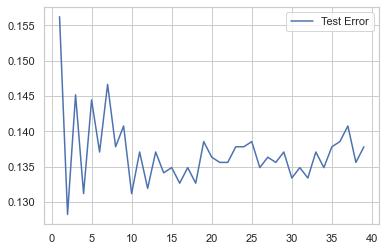

```python
import matplotlib.pyplot as plt
test_error=[]
for n in range(1,40):
    model = RandomForestClassifier(n_estimators=n,max_features='auto',random_state=101)
    model.fit(X_train,y_train.ravel())
    preds=model.predict(X_test)
    test_error.append(1-accuracy_score(preds,y_test))

plt.plot(range(1,40),test_error,label='Test Error')
plt.legend()
```

```python
clf = RandomForestClassifier(n_estimators=7)
clf.fit(X_train, y_train.ravel())
prediction_1 = clf.predict(X_test)
print("Accuracy is : ",accuracy_score(prediction_1, y_test))
print("=====================================================")
print(classification_report(prediction_1, y_test))
```

```
Accuracy is :  0.8636698599852616
=====================================================
              precision    recall  f1-score   support

           0       0.93      0.92      0.92      1207
           1       0.39      0.40      0.39       150

    accuracy                           0.86      1357
   macro avg       0.66      0.66      0.66      1357
weighted avg       0.87      0.86      0.86      1357
```

```python
clf = RandomForestClassifier(n_estimators=10)
clf.fit(X_train, y_train.ravel())
prediction_1 = clf.predict(X_test)
print("Accuracy is : ",accuracy_score(prediction_1, y_test))
print("=====================================================")
print(classification_report(prediction_1, y_test))
```

```
Accuracy is :  0.8680913780397936
=====================================================
              precision    recall  f1-score   support

           0       0.94      0.91      0.93      1235
           1       0.32      0.40      0.35       122

    accuracy                           0.87      1357
   macro avg       0.63      0.66      0.64      1357
weighted avg       0.88      0.87      0.88      1357
```